# Procedure time for fEVAR in GG&C

Martin Hennessy

2023-07-25

# 1 Procedure times for fEVAR performed in GG&C

- This document contains data about 86 fEVAR/bEVAR performed in GG&C between 17 December 2009 and 16 June 2023.
- The two important concepts addressed are ‘device time’ and ‘theatre time’.

## 1.1 Device time and theatre time

- It is a standard procedure to perform an angiogram prior to opening an aortic stent-graft with the un-opened device in situ and a pigatil catheter from the contralateral side.
- It is also a standard procedure to perform an angiogram after all stent-grafts have been deployed.
- We define the time between these angiograms as ‘device time’ - this is the time required to deploy all devices, cannulate all vessels, balloon overlaps etc and is a reasonable standardised measured of the efficiency of the procedure.
- The times are taken from the PACS images and therefore rely on these being available.
- In GG&C, we have device time for 81 fEVAR/bEVAR (04 February 2015 - 16 June 2023.)
- Theatre time is a measure of how long the patient spends in the operating theatre.
- It is calculcated using the anaesthetists monitoring chart and is taken as the time between the first and last set of documented observations.
- It may therefore underestimate the time the patient spends in theatre in some cases.
- In GG&C, we have theatre time for 78 fEVAR/bEVAR (10 March 2015 - 16 June 2023.)

## 1.2 Important considerations and change in practice over time

- It is important to note that in 2020, GG&C moved from using Vascutek Anaconda to Cook Zenith custom-made devices.
- In addition, procedure number increased since this change.
- These changes will be largely hidden in the figures and tables below and so the following table is included for reference:

*Number of cases per year (n)*

|  | **Year** **2015** | **Year** **2016** | **Year** **2017** | **Year** **2018** | **Year** **2019** | **Year** **2020** | **Year** **2021** | **Year** **2022** | **Year** **2023** |
| --- | --- | --- | --- | --- | --- | --- | --- | --- | --- |
| Device |  |  |  |  |  |  |  |  |  |
| Anaconda | 2 | 3 | 7 | 6 | 5 | 2 | 0 | 0 | 0 |
| Zenith | 0 | 0 | 0 | 0 | 0 | 5 | 19 | 22 | 10 |

- An overall look at device time and theatre time will help decide how to report summary statistics.
- Below is a histogram of both:

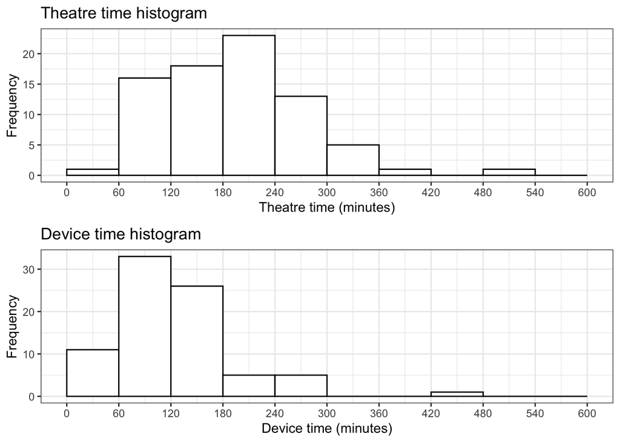

- Device time looks clearly abnormally distributed and theatre time probably is too (both can be confirmed by Shapiro Wilk test).
- As such we will report medians and interquartile range, rather than means and standard deviation.

# 2 Device time

## 2.1 Number of fenestrations

- The number of fenestrations (or branches) to be cannulated may impact on device time.
- This is shown in the boxplot below:

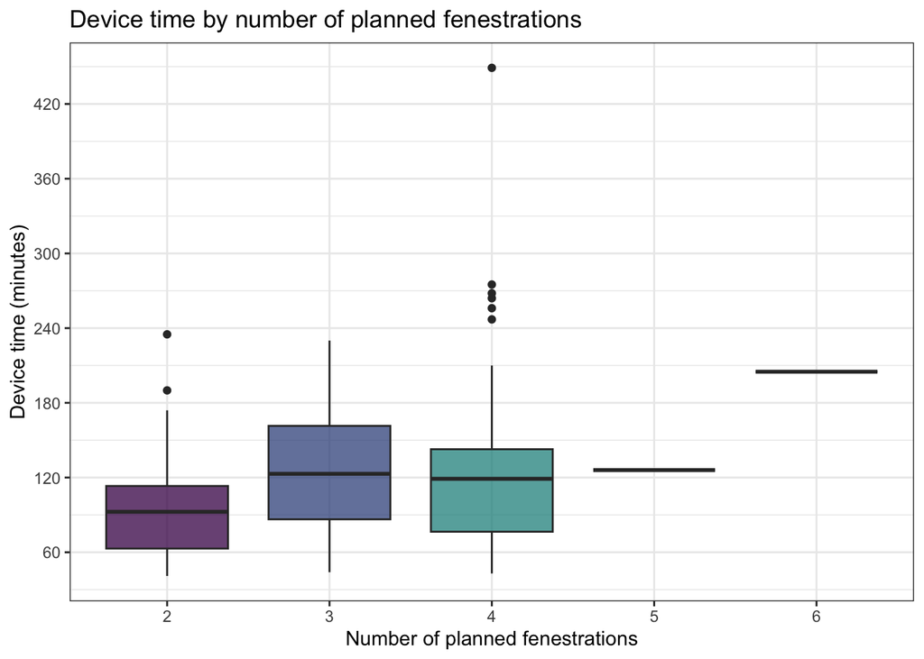

## 2.2 Type of custom-made graft

- Endografts with branches exclusively or in addition to fenestrations may impact on device time.
- This is shown in the boxplot below:

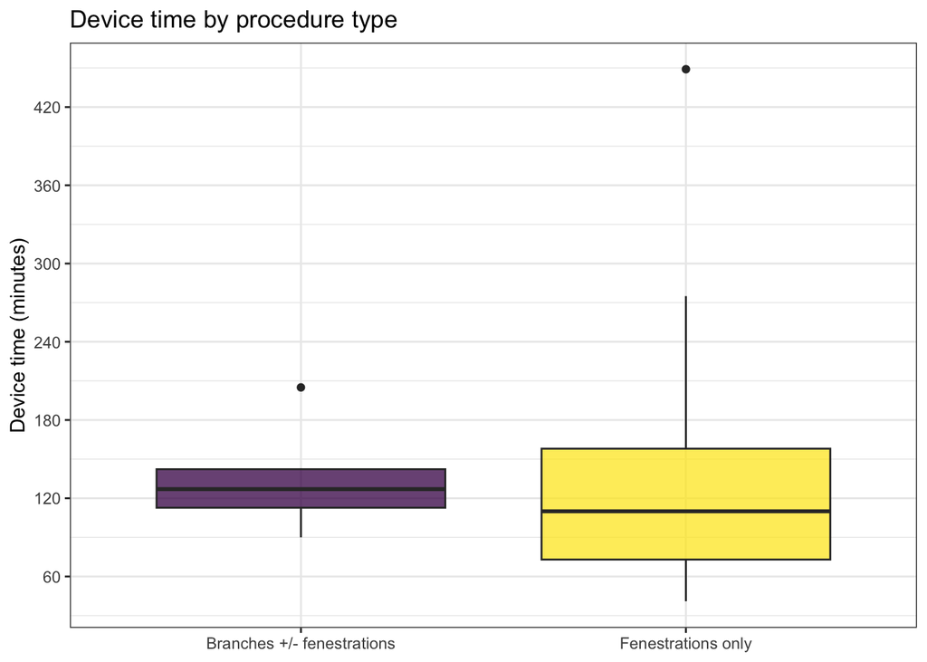

## 2.3 Aneurysm classification

- The extent of the aneurysm being treated, whether thoraco-abdominal or juxta-renal, may impact on device time.
- This is shown in the boxplot below:

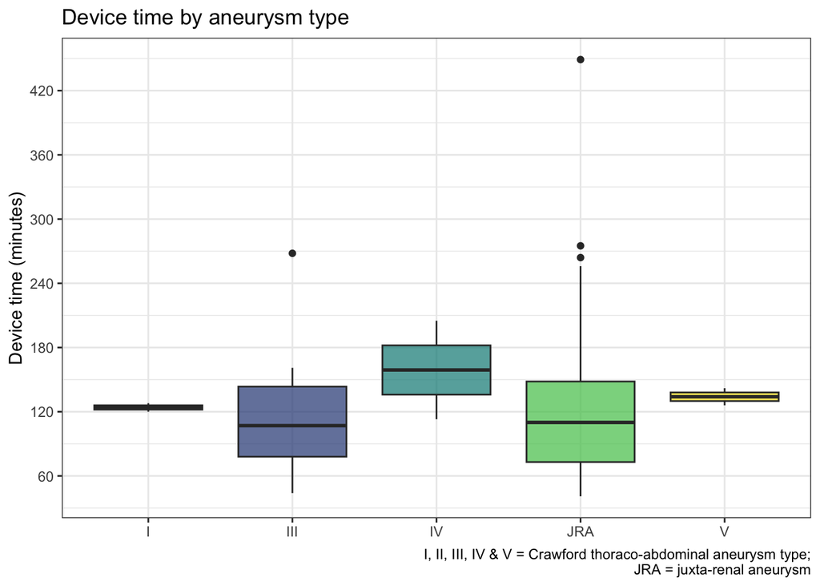

## 2.4 Stent-graft used

- Different stent-grafts may impact on device time.
- In addition it should be remembered that initial experience was gained using the Anaconda platform before moving to Zenith and markedly increaseing case numbers (see table above).
- This is shown in the boxplot below:

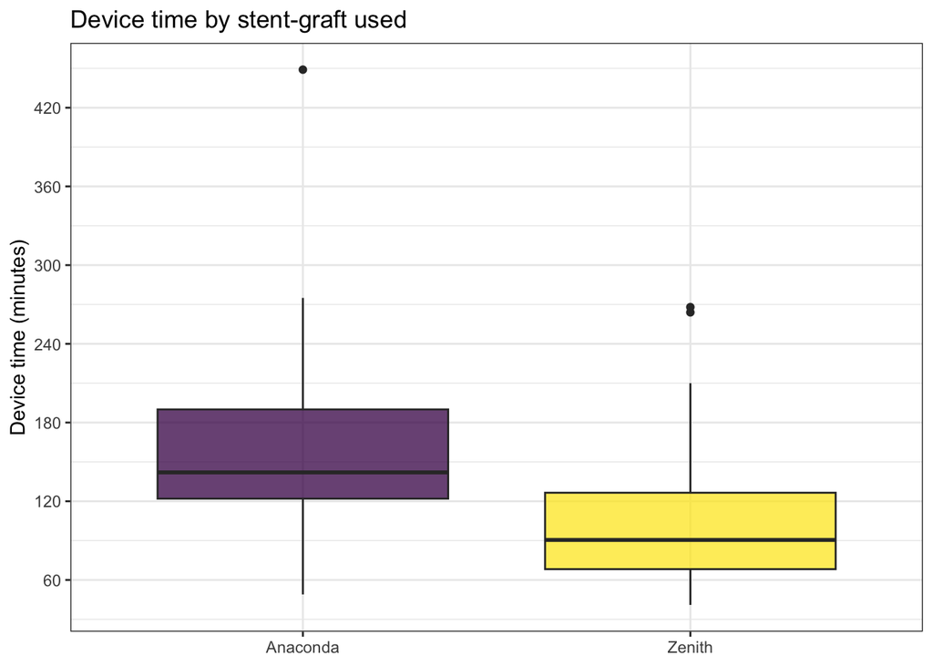

## 2.5 Year of procedure

- With increasing experience, device time may also decrease.
- The is shown in the boxplot below.
- In addition, due to the switch from Anaconda to Zenith in 2020, these categories are also displayed.

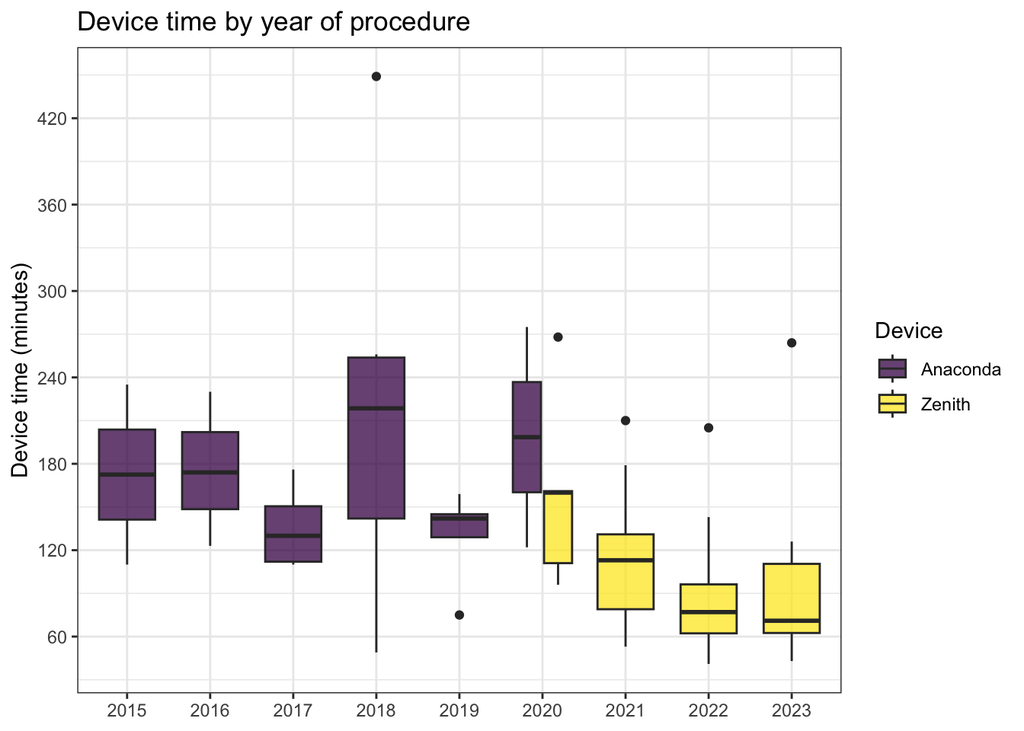

## 2.6 Anaesthetic used

- As confidence with the procedure has grown, we have increasingly used local anaesthetic where appropriate for these cases.
- Effect on device time is shown in the boxplot below:

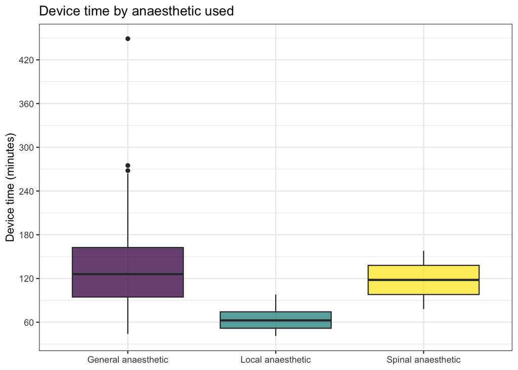

## 2.7 Tabulated display of device time

- For those who prefer a numerical representation of the date to a visual one:

|  | **Device time (minutes):** *Median (IQR)* |
| --- | --- |
| Fenestrations/branches |  |
| 2 | 93 (63, 113) |
| 3 | 123 (87, 162) |
| 4 | 119 (77, 143) |
| 5 | 126 (126, 126) |
| 6 | 205 (205, 205) |
| Type of CMD |  |
| Branches +/- fenestrations | 127 (113, 142) |
| Fenestrations only | 110 (73, 158) |
| Aneurysm type |  |
| I | 124 (122, 126) |
| III | 107 (78, 144) |
| IV | 159 (136, 182) |
| JRA | 110 (73, 148) |
| V | 134 (130, 138) |
| Device |  |
| Anaconda | 142 (122, 190) |
| Zenith | 91 (68, 127) |
| Year |  |
| 2015 | 173 (141, 204) |
| 2016 | 174 (149, 202) |
| 2017 | 130 (112, 151) |
| 2018 | 219 (142, 254) |
| 2019 | 142 (129, 145) |
| 2020 | 160 (117, 215) |
| 2021 | 113 (79, 131) |
| 2022 | 77 (62, 96) |
| 2023 | 71 (63, 111) |
| Anaesthesia |  |
| General anaesthetic | 126 (95, 163) |
| Local anaesthetic | 63 (52, 74) |
| Spinal anaesthetic | 118 (98, 138) |

# 3 Theatre time

- As device time is a subset of theatre time, we have chosen fewer visualisations of theatre time.
- The year of the procedure reflects institutional experience with the procedure which may decrease the theatre time.
- As above, we have incorporated the stent-graft used into the ‘year’ plot.
- The anaesthetic method is the main factor we believe will affect theatre time and so it is also presented.

## 3.1 Year of procedure

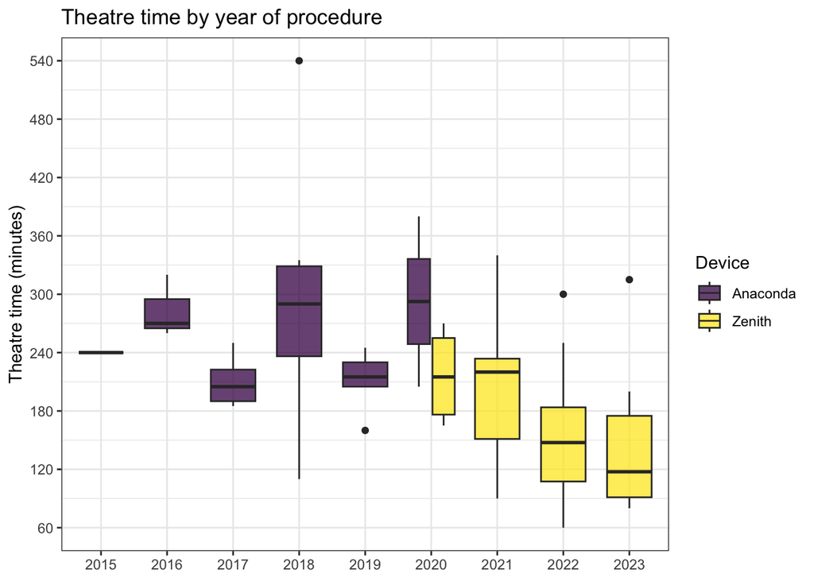

## 3.2 Anaesthetic used

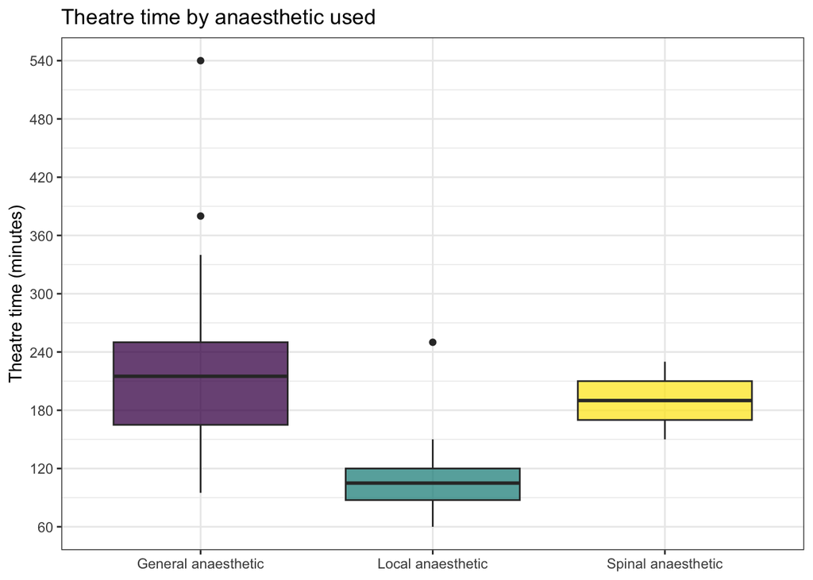

## 3.3 Tabulated display of theatre time

- For those who prefer a numerical representation of the date to a visual one:

|  | **Theatre time (minutes):** *Median (IQR)* |
| --- | --- |
| Year |  |
| 2015 | 240 (240, 240) |
| 2016 | 270 (265, 295) |
| 2017 | 205 (190, 223) |
| 2018 | 290 (236, 329) |
| 2019 | 215 (205, 230) |
| 2020 | 228 (186, 265) |
| 2021 | 220 (151, 234) |
| 2022 | 148 (108, 184) |
| 2023 | 118 (91, 175) |
| Anaesthesia |  |
| General anaesthetic | 215 (165, 250) |
| Local anaesthetic | 105 (88, 120) |
| Spinal anaesthetic | 190 (170, 210) |